# Verify Wind

REsurety, Inc.

February 2016

## REsurety Software Development Task

We have received a new cluster of wind data sources that are near Logan Wind Energy, an operating wind project. Your goal is to analyze whether the new wind data can be used to model long-term conditions at the wind farm. Your answer should have a quantitative statistical answer and a visual component.

Your data sources are:

- `WindData.csv` - hourly wind speed, direction, and temperature back to 1979
- `SiteData.csv` - data about Logan such as owner, location, and turbine specifications
- `PowerCurve.csv` - relates wind speed to turbine power production and thrust
- `SiteEnergy.csv` - shows historical energy production at Logan

The following sections describe each data source in detail and describe the expected deliverables. Expected time for the task is ~2 hours.

## Data Source #1: Wind Time Series

The file `WindData.csv` contains wind data from a meteorological site at latitude 41.0 and longitude -103.3333, to the North and West of Logan. Columns in the file are:

- `Time` - hourly data going back to 1979 in UTC
- `NW_spd_w2`, `NW_spd_w10`, `NW_spd_50m` Wind speed at 2m, 10m, and 50m (m/s)
- `NW_dir_w2`, `NW_dir_w10`, `NW_dir_50m` Wind direction at 2m, 10m, and 50m (degrees, 0 = North)
- `NW_t2m` - Temperature at 2m

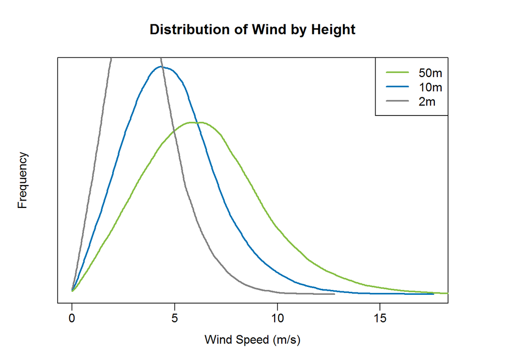

## Data Source #2: Site Characteristics

The wind project we are evaluating has all its site characteristics saved in the file `SiteData.csv`:

```
##                               SiteData                    Description
## EIA.ID                           56613           Energy Info Admin ID
## FERC.ID                           1881         Fed Energy Reg Cmsn ID
## Plant.Name           Logan Wind Energy
## Operator.Name                  NextEra
## Loc.Lat                       40.94852  Latitude, decimal coordinates
## Loc.Lon                      -103.2447 Longitude, decimal coordinates
## Loc.Elev                      1393.448        Mean site elevation (m)
## Loc.County                       Logan
## Loc.State                           CO
## Loc.Country                         US
## Status                              OP     Operational or development
## Date.Cmsn                      2007-10     Date commissioned, YYYY-MM
## Turbine.Manufacturer                GE
## Turbine.Model                   1.5SLE
## Turbine.Capacity                   1.5 Max power of each turbine (MW)
## Tower.HH                            80                 Hub height (m)
## Rotor.Diameter                      77             Rotor diameter (m)
## Capacity                           201        Max sitewide power (MW)
## Turbine.Ct                         134             Number of turbines
```

## Data Source #3: Turbine Power Curve

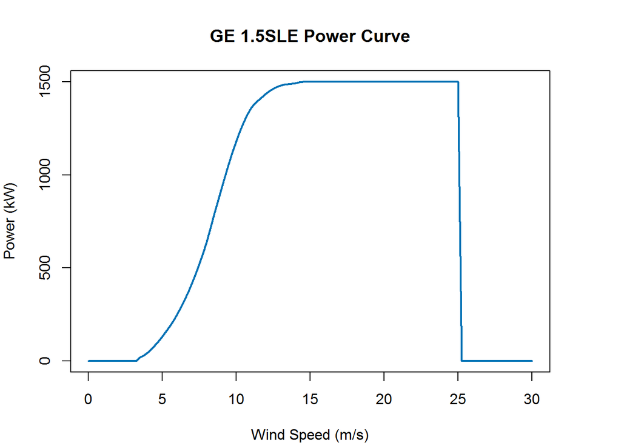

## Data Source #4: Site Energy Production

The file `SiteEnergy.csv` contains public records for Logan Wind Energy’s monthly energy production. Columns are:

- `Month` - YYYY-MM of record
- `Energy.MWh` - Megawatt-hours of reported site production in that month
- `Capacity.MW` - The total nameplate capacity (in MW) reported by the site

```
##       Month Energy.MWh Capacity.MW     Year
## 100 2015-04      47862         201 2015.250
## 101 2015-05      42067         201 2015.333
## 102 2015-06      23941         201 2015.417
## 103 2015-07      28072         201 2015.500
## 104 2015-08      35168         201 2015.583
## 105 2015-09      30737         201 2015.667
```

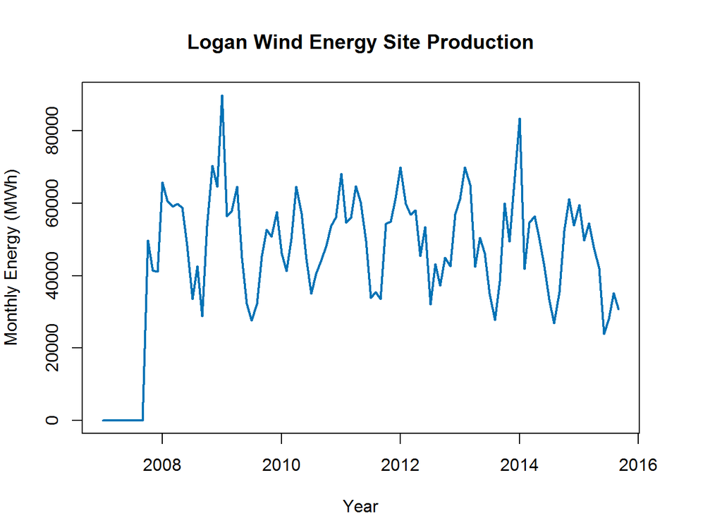

## Hints

Your workflow may resemble the following:

- Transform an appropriate hourly wind speed using the power curve to get hourly energy production
- Aggregate hourly energy production to the monthly level
- Compare modeled monthly energy to the publicly reported observed energy

## Deliverables

Submit the following to `kcritz@resurety.com` as PDF or HTML files:

- Your contact information
- A 3-4 sentence answer to the question “Is the met data suitable to predict energy output at the site?” This answer should have a quantitative component.
- A visualization that illustrates your point. Charts will be evaluated according to Tufte’s “Visual Display of Quantitative Information” http://www.edwardtufte.com/tufte/books_vdqi
- The code you used to answer the question. Use any analysis environment that works for you. If you use Excel, we will laugh at you.
- Is there anything we can do to improve this exercise? Was anything unclear or ambiguous?

Expectations:

- Most candidates spend no more than 2 hours on this task. This isn’t meant to be an in-depth consulting project or second job. Obviously we can’t enforce a time limit, but you shouldn’t let this eat your time.
- Results should reflect your work only. This is not a group project.
- If you have domain knowledge, don’t worry about nonlinear shear, time zone corrections, or wake/performance losses. This investigation is meant to be approximate and fast. No extra credit will be given if you build a terrain map and locate turbines to run a full CFD simulation of the site.